# Algumas Opções de Temas e Análise Bivariada com Variáveis Quantitativas e Qualitativas

# Algumas Opções de Temas e Análise Bivariada com Variáveis Quantitativas e Qualitativas

Nesta aula, exploraremos análises bivariadas utilizando variáveis quantitativas e qualitativas do conjunto de dados `diamonds`. Abordaremos a utilização da função `top_n`, criaremos gráficos personalizados com o `ggplot2`, detalharemos cada camada e parâmetro utilizado, e aprenderemos a salvar os gráficos em formatos PDF e de imagem.

## Carregando Pacotes Necessários

Primeiramente, carregaremos os pacotes necessários para a análise e visualização de dados.

```r
library(tidyverse)  # Conjunto de pacotes para manipulação e visualização de dados
library(forcats)    # Pacote para manipulação de fatores
```

## Preparando a Base de Dados

Utilizaremos o conjunto de dados `diamonds`, que está disponível no pacote `ggplot2`. Este conjunto de dados contém informações sobre diamantes, incluindo características físicas e preço.

```r
data(diamonds)  # Carrega o conjunto de dados diamonds
tb_diamonds <- as_tibble(diamonds)  # Converte para tibble para melhor manipulação
glimpse(tb_diamonds)  # Visualiza a estrutura dos dados
```

```
Rows: 53,940
Columns: 10
$ carat   <dbl> 0.23, 0.21, 0.23, 0.29, 0.31, 0.24, 0.24, 0.26, 0.22, 0.23, 0.30, 0.23, 0.22, 0.31, 0.20, 0.32, 0.30, 0.30, 0.30, 0.30, 0.30,…
$ cut     <ord> Ideal, Premium, Good, Premium, Good, Very Good, Very Good, Very Good, Fair, Very Good, Good, Ideal, Premium, Ideal, Premium, …
$ color   <ord> E, E, E, I, J, J, I, H, E, H, J, J, F, J, E, E, I, J, J, J, I, E, H, J, J, G, I, J, D, F, F, F, E, E, D, F, E, H, D, I, I, J,…
$ clarity <ord> SI2, SI1, VS1, VS2, SI2, VVS2, VVS1, SI1, VS2, VS1, SI1, VS1, SI1, SI2, SI2, I1, SI2, SI1, SI1, SI1, SI2, VS2, VS1, SI1, SI1,…
$ depth   <dbl> 61.5, 59.8, 56.9, 62.4, 63.3, 62.8, 62.3, 61.9, 65.1, 59.4, 64.0, 62.8, 60.4, 62.2, 60.2, 60.9, 62.0, 63.4, 63.8, 62.7, 63.3,…
$ table   <dbl> 55, 61, 65, 58, 58, 57, 57, 55, 61, 61, 55, 56, 61, 54, 62, 58, 54, 54, 56, 59, 56, 55, 57, 62, 62, 58, 57, 57, 61, 57, 57, 5…
$ price   <int> 326, 326, 327, 334, 335, 336, 336, 337, 337, 338, 339, 340, 342, 344, 345, 345, 348, 351, 351, 351, 351, 352, 353, 353, 353, …
$ x       <dbl> 3.95, 3.89, 4.05, 4.20, 4.34, 3.94, 3.95, 4.07, 3.87, 4.00, 4.25, 3.93, 3.88, 4.35, 3.79, 4.38, 4.31, 4.23, 4.23, 4.21, 4.26,…
$ y       <dbl> 3.98, 3.84, 4.07, 4.23, 4.35, 3.96, 3.98, 4.11, 3.78, 4.05, 4.28, 3.90, 3.84, 4.37, 3.75, 4.42, 4.34, 4.29, 4.26, 4.27, 4.30,…
$ z       <dbl> 2.43, 2.31, 2.31, 2.63, 2.75, 2.48, 2.47, 2.53, 2.49, 2.39, 2.73, 2.46, 2.33, 2.71, 2.27, 2.68, 2.68, 2.70, 2.71, 2.66, 2.71,…
```

## Selecionando os Top 40 Diamantes por Preço

Utilizaremos a função `top_n` para selecionar os 40 diamantes mais caros do conjunto de dados.

```r
tb_top_price <- tb_diamonds %>%
    top_n(price, n = 40)  # Seleciona os 40 diamantes com maior preço

tb_top_price
```

| carat | cut | color | clarity | depth | table | price | x | y | z |
| --- | --- | --- | --- | --- | --- | --- | --- | --- | --- |
| 2.01 | Premium | G | SI2 | 61.2 | 57.2 | 18705 | 8.08 | 8.14 | 4.97 |
| 2.22 | Premium | J | VS1 | 60.0 | 60.0 | 18706 | 8.49 | 8.43 | 5.08 |
| 2.07 | Good | I | VS2 | 61.8 | 61.0 | 18707 | 8.12 | 8.16 | 5.03 |
| 2.00 | Very Good | E | SI1 | 60.5 | 59.0 | 18709 | 8.09 | 8.14 | 4.94 |
| 3.01 | Premium | J | SI2 | 60.7 | 59.0 | 18710 | 9.35 | 9.22 | 5.64 |
| 3.01 | Premium | J | SI2 | 59.7 | 58.0 | 18710 | 9.41 | 9.32 | 5.59 |
| 2.18 | Premium | F | SI1 | 61.2 | 60.0 | 18717 | 8.38 | 8.30 | 5.10 |
| 1.70 | Premium | G | VVS2 | 59.8 | 59.0 | 18718 | 7.70 | 7.75 | 4.62 |
| 1.51 | Ideal | E | VS1 | 61.5 | 57.0 | 18729 | 7.34 | 7.40 | 4.53 |
| 1.72 | Premium | G | VVS2 | 61.8 | 60.0 | 18730 | 7.65 | 7.68 | 4.74 |

[output cut: 30 more lines]

### Explicação da Função `top_n`

- **`top_n(price, n = 40)`**: Seleciona as linhas com os maiores valores na coluna `price`. Aqui, `n = 40` indica que queremos os 40 maiores valores.

## Criando um Gráfico de Dispersão Personalizado

### Código do Gráfico

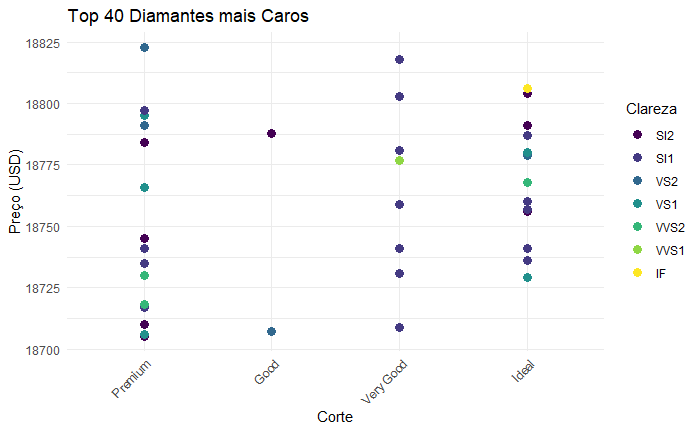

```r
ggplot(data = tb_top_price,
       mapping = aes(x = fct_reorder(cut, price, .fun = median),
                     y = price,
                     color = clarity)) +
    geom_point(size = 3) +
    theme_minimal() +
    labs(title = "Top 40 Diamantes mais Caros",
         x = "Corte",
         y = "Preço (USD)",
         color = "Clareza") +
    theme(axis.text.x = element_text(angle = 45, hjust = 1))
```

## Modificando os Eixos e Removendo a Rotação

Agora, modificaremos os eixos para trocar `x` e `y`, e removeremos a rotação de 45 graus.

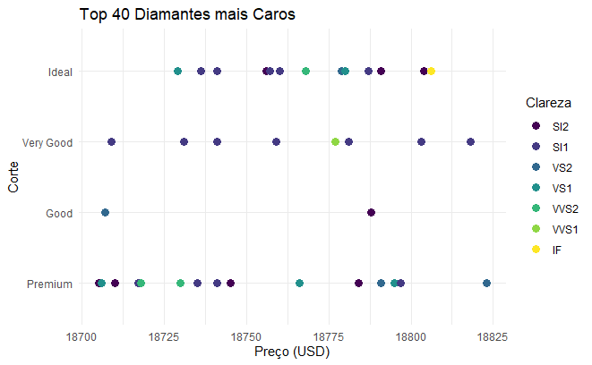

### Detalhamento das Alterações

1. **Troca de `x` e `y`**:
   - **`x = price`**: Define o eixo x como o preço.
   - **`y = fct_reorder(cut, price, .fun = median)`**: Define o eixo y como o corte, reordenado pela mediana do preço.
2. **Remoção da Rotação**:
   - **`axis.text.y = element_text(angle = 0, hjust = 1)`**: Mantém os textos do eixo y sem rotação.

## Selecionando os Top 40 Diamantes por Quilates

Vamos agora selecionar os 40 diamantes com maior peso em quilates (`carat`).

[figure not shown]

### Criando um Gráfico de Dispersão com Labels

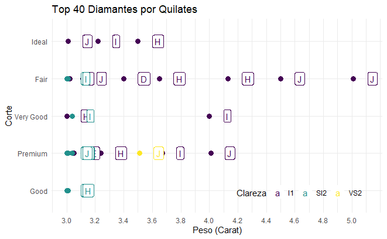

### Detalhamento de Cada Camada e Parâmetro

1. **`geom_label(aes(label = color), hjust = 0, nudge_y = 0.1)`**:
   - **`geom_label`**: Adiciona rótulos aos pontos.
   - **`aes(label = color)`**: Define que os rótulos serão baseados na variável `color`.
   - **`hjust = 0`**: Justifica horizontalmente os rótulos à esquerda.
   - **`nudge_y = 0.1`**: Desloca os rótulos ligeiramente no eixo y para evitar sobreposição com os pontos.
2. **`scale_y_continuous(breaks = seq(min(tb_diamonds$carat), max(tb_diamonds$carat), by = 0.2))`**:
   - Define os intervalos das quebras no eixo y em incrementos de 0.2 carates.
3. **`coord_flip()`**:
   - Inverte os eixos x e y, facilitando a visualização quando há muitas categorias no eixo y.
4. **`theme(...)`**:
   - **`legend.position = c(0.95, 0.05)`**: Posiciona a legenda no canto inferior direito.
   - **`legend.justification = c(1, 0)`**: Justifica a legenda em relação à posição especificada.
   - **`legend.direction = "horizontal"`**: Organiza os itens da legenda horizontalmente.

## Representando uma Variável Métrica em Função de uma Variável Categórica

Queremos observar como o preço dos diamantes varia de acordo com o corte (`cut`). Para isso, criaremos diferentes tipos de gráficos.

### Inicializando um Objeto ggplot

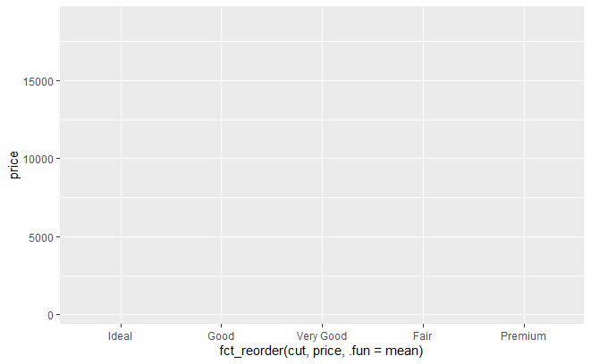

### Adicionando Distribuição dos Pontos com `geom_jitter`

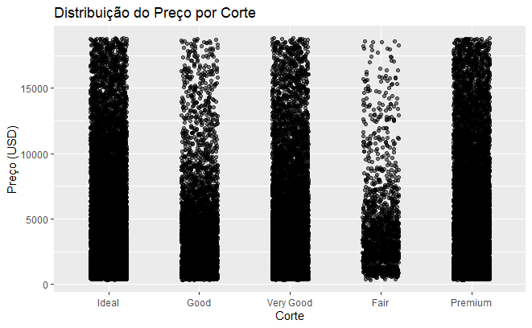

### Adicionando Tamanho e Transparência

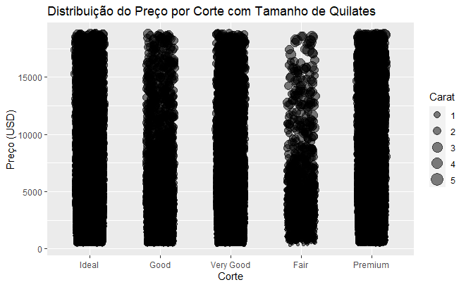

### Construção de um Box Plot

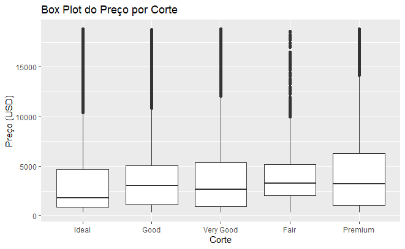

### Construção de um Violin Plot

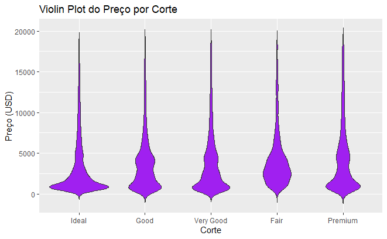

### Adicionando a Média ao Violin Plot

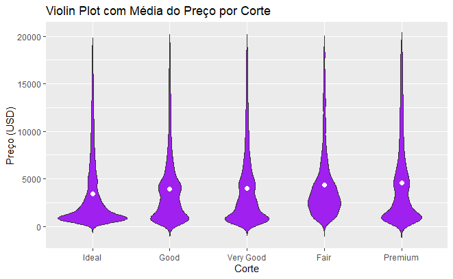

## Construção das Variáveis para o Gráfico de Distribuição

Vamos criar variáveis que permitem comparar a distribuição real dos preços com uma distribuição normal.

| cut | x | y_norm | y_kernel |
| --- | --- | --- | --- |
| Fair | -1114.869447 | 3.437042e-05 | 6.744087e-08 |
| Fair | -1073.498138 | 3.498757e-05 | 9.022150e-08 |
| Fair | -1032.126829 | 3.561099e-05 | 1.196403e-07 |
| Fair | -990.755520 | 3.624063e-05 | 1.572893e-07 |
| Fair | -949.384211 | 3.687642e-05 | 2.064376e-07 |
| Fair | -908.012902 | 3.751830e-05 | 2.708506e-07 |
| Fair | -866.641593 | 3.816620e-05 | 3.524174e-07 |
| Fair | -825.270284 | 3.882004e-05 | 4.548266e-07 |
| Fair | -783.898975 | 3.947975e-05 | 5.823394e-07 |
| Fair | -742.527666 | 4.014526e-05 | 7.398368e-07 |

[output cut: 990 more lines]

### Transformando os Dados para o Formato Longo

### Plotando as Distribuições

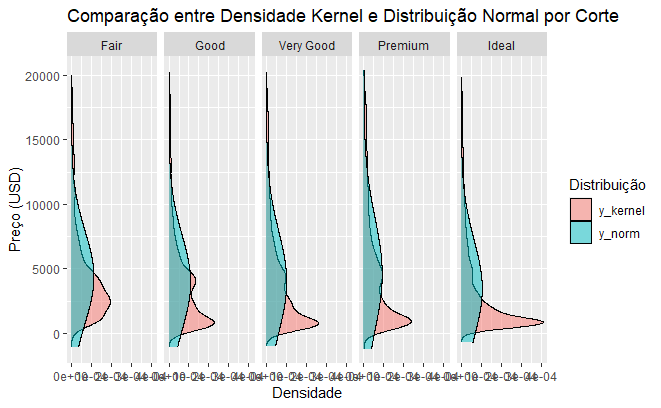

### Escalonando a Densidade para Cada Corte

### Plotando as Distribuições Escalonadas

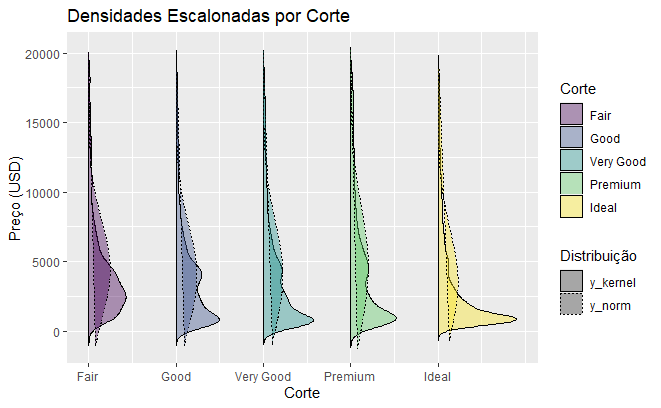

## Salvando Gráficos em Formato PDF e PNG

Após criar os gráficos, podemos salvá-los em diferentes formatos para utilização futura ou apresentação.

### Salvando um Gráfico como PDF

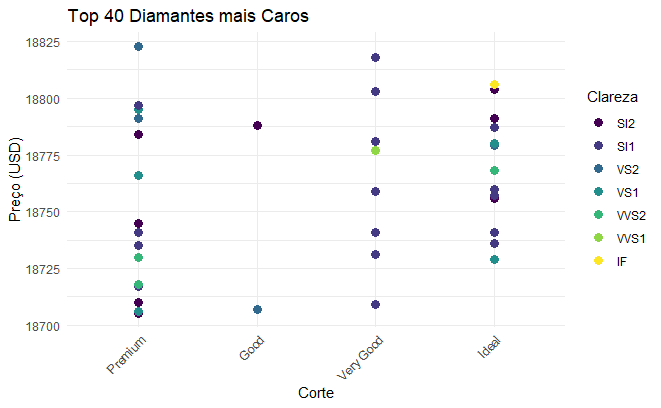

### Salvando um Gráfico como PNG

```r
# Salva o gráfico como PNG
ggsave(filename = "top40_diamonds_price.png",
       plot = plot_pdf,
       width = 8,
       height = 6,
       units = "in",
       dpi = 300)  # Define a resolução
```

### Explicação da Função `ggsave`

- **`filename`**: Nome do arquivo de saída, incluindo a extensão que determina o formato (e.g., `.pdf`, `.png`).
- **`plot`**: O objeto ggplot que será salvo. Se omitido, `ggsave` salvará o último gráfico exibido.
- **`width` e `height`**: Define as dimensões do gráfico em unidades especificadas (neste caso, polegadas).
- **`units`**: Unidade de medida para `width` e `height` (e.g., `"in"` para polegadas, `"cm"` para centímetros).
- **`dpi`**: Resolução do gráfico (dots per inch), aplicável para formatos de imagem como PNG.

## Exemplos de Salvamento de Gráficos

Além dos exemplos fornecidos no notebook acima, seguem mais algumas maneiras de salvar gráficos em diferentes formatos:

### Salvando com `pdf()`

```r
# Abre um dispositivo PDF
pdf("grafico_violin.pdf", width = 8, height = 6)

# Cria e plota o gráfico
ggplot(data = tb_diamonds,
       mapping = aes(x = cut, y = price)) +
    geom_violin(fill = "lightblue") +
    labs(title = "Violin Plot do Preço por Corte",
         x = "Corte",
         y = "Preço (USD)")

# Fecha o dispositivo PDF
dev.off()
```

### Salvando com `png()`

```r
# Abre um dispositivo PNG
png("grafico_violin.png", width = 800, height = 600)

# Cria e plota o gráfico
ggplot(data = tb_diamonds,
       mapping = aes(x = cut, y = price)) +
    geom_violin(fill = "lightgreen") +
    labs(title = "Violin Plot do Preço por Corte",
         x = "Corte",
         y = "Preço (USD)")

# Fecha o dispositivo PNG
dev.off()
```

### Utilizando `ggsave` com Outros Formatos

A função `ggsave` também suporta outros formatos como JPEG, TIFF, etc. Basta alterar a extensão do `filename`.

```r
# Salva como JPEG
ggsave(filename = "grafico_violin.jpeg",
       plot = last_plot(),
       width = 8,
       height = 6,
       units = "in",
       dpi = 300)
```

## Considerações Finais

A capacidade de criar visualizações informativas e salvá-las em formatos apropriados é essencial para comunicar insights de dados de maneira eficaz. O `ggplot2` oferece uma ampla gama de possibilidades para personalizar gráficos, e funções como `ggsave` facilitam o armazenamento e compartilhamento desses gráficos.

## Conclusão

Nesta aula, exploramos como realizar análises bivariadas utilizando variáveis quantitativas e qualitativas no conjunto de dados `diamonds`. Aprendemos a utilizar funções como `top_n` para selecionar subconjuntos de dados, criar gráficos personalizados com `ggplot2`, detalhar cada camada e parâmetro dos gráficos, e salvar os gráficos em formatos PDF e PNG para uso posterior. Essas habilidades são fundamentais para a análise e visualização eficaz de dados em diversas aplicações.